# Anonymize Survey

Augustina Ragwitz

```r
library(dplyr)
```

```r
library(ggplot2)
library(httr)
library(jsonlite)
library(readr)
library(stringr)
```

## Survey Results

Read in a CSV of the survey results. These are not included in the repo because they have not been anonymized yet.

```r
raw_survey <- read_csv(params$survey_file)
survey_data_anon <- data_frame()
```

## IP Address

We should remove the IP Address because it is too specific of an identifier. The plot below shows that in most cases a single IP address only had one respondee.

```r
ip_summary <- raw_survey %>%
  group_by(`ipaddr. IP address`) %>%
  summarise(total_respondants=n()) %>%
  ungroup() %>%
  group_by(total_respondants) %>%
  summarise(total_ips=n(), needs_anon = first(total_respondants) < 25) %>%
  arrange(-total_ips)

write_csv(ip_summary, "data/raw_survey_ip_summary.csv")

ip_summary
```

```
## # A tibble: 10 x 3
##    total_respondants total_ips needs_anon
##                <int>     <int> <lgl>
##  1                 1      3327 TRUE
##  2                 2        55 TRUE
##  3                 3         7 TRUE
##  4                 4         4 TRUE
##  5                 6         2 TRUE
##  6                 5         1 TRUE
##  7                 7         1 TRUE
##  8                 9         1 TRUE
##  9                10         1 TRUE
## 10               101         1 FALSE
```

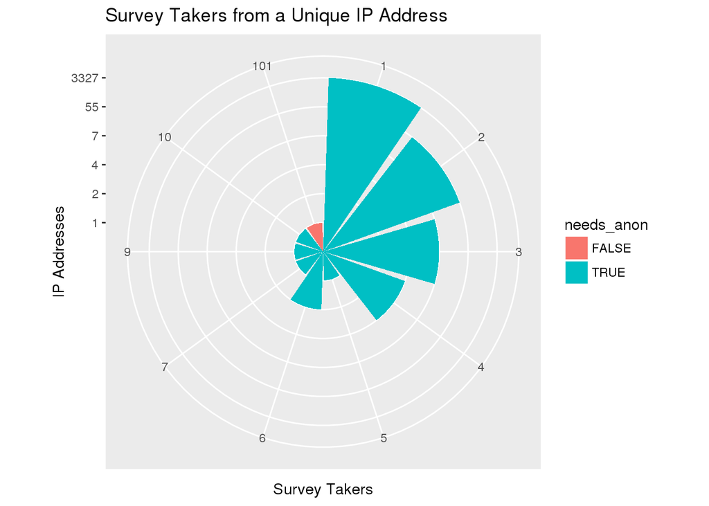

```r
ggplot(ip_summary,
       aes(y=factor(total_ips), x=factor(total_respondants))) +
  geom_bar(aes(fill=needs_anon), stat="identity") +
  coord_polar() +
  labs(y = "IP Addresses", x = "Survey Takers", title="Survey Takers from a Unique IP Address")
```

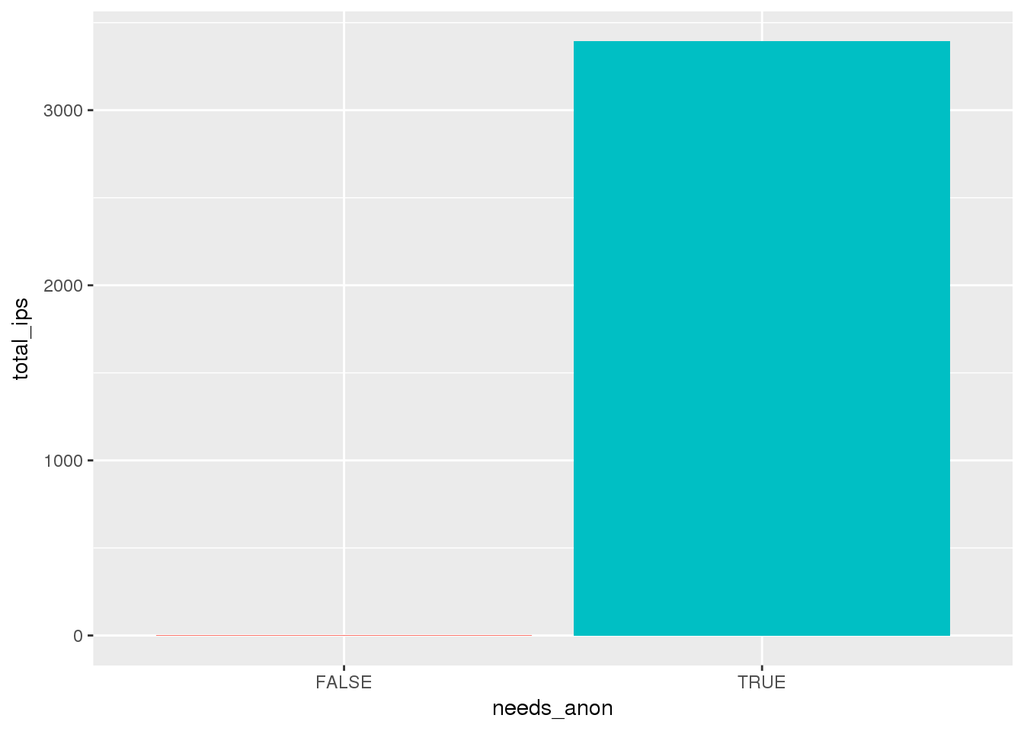

```r
ggplot(ip_summary, aes(x=needs_anon, y=total_ips, fill=needs_anon)) +
  geom_bar(stat="sum", show.legend = FALSE)
```

My recommendation is to convert the IP address to a country.

```r
get_country_from_ip <- function(ip) {
  url <- paste0("http://freegeoip.net/json/", ip)
  geoip_req <- GET(url)
  geoip <- fromJSON(content(geoip_req, as = "text"), flatten=TRUE)
  return(geoip)
}

# This needs to be done in a for loop because it can fail,
#  rather than starting over, it's easier to set n to the failure point

ip_address_country <- data_frame()

for(n in 1:nrow(raw_survey)) {
  ip <- raw_survey$`ipaddr. IP address`[n]

  if(ip == "Invalid") {
    geoip <- data_frame(ip=ip) # remaining fields will be NA on join later
  } else {
    print(paste("Looking up", n, ip))
    geoip <- as_data_frame(get_country_from_ip(ip)) %>%
      select(ip, country_code, country_name, time_zone)
  }

  ip_address_country <- bind_rows(ip_address_country, geoip)

}

ip_address_country <- ip_address_country %>%
  unique()

# convert blanks to NA
ip_address_country[ip_address_country==""]  <- NA
```

## Origin Parameter

The origin from URL parameter is mostly ok, but some meetup groups are mentioned by name. Often member lists are public. These are only in a minority of responses but depending on the nature of the free text, one could potentially track someone down.

```r
origin_summary <- raw_survey %>%
  rename(origin=`origin. Origin from URL parameters`) %>%
  mutate(origin=str_replace_all(origin, "[^A-Za-z]", "")) %>% # clean up the dupes with extra characters
  group_by(origin) %>%
  summarise(total_respondants=n())

write_csv(origin_summary, "data/raw_survey_origin_summary.csv")

sum_respondants <- sum(origin_summary$total_respondants)

origin_summary
```

```
## # A tibble: 11 x 2
##    origin                  total_respondants
##    <chr>                               <int>
##  1 advtweet                                3
##  2 berlinrusersmeetupgroup                 6
##  3 datacamp                               75
##  4 hungarianrmeetup                       18
##  5 londonR                                 1
##  6 rconsortiumblog                      2545
##  7 revoblog                              511
##  8 TIBCO                                  12
##  9 twitter                               100
## 10 yihui                                  61
## 11 <NA>                                  286
```

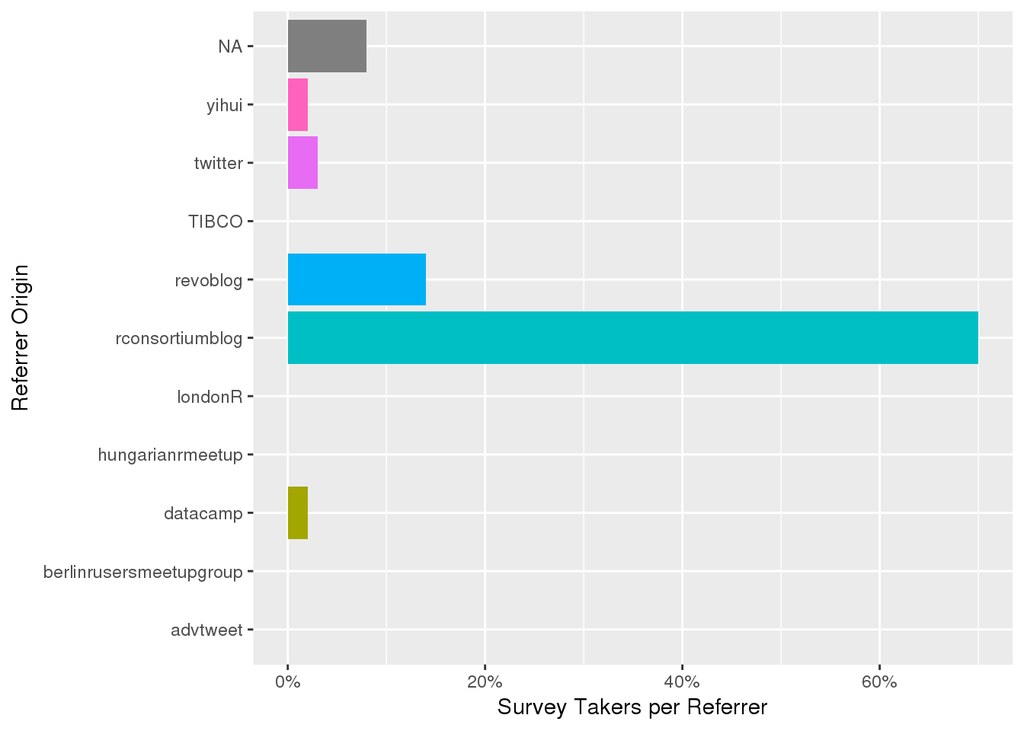

```r
ggplot(origin_summary, aes(x=origin, y=round(total_respondants/sum_respondants, 2))) +
  geom_bar(aes(fill=origin), stat="identity", show.legend = FALSE) +
  coord_flip() +
  scale_y_continuous(labels=scales::percent) +
  labs(x = "Referrer Origin", y = "Survey Takers per Referrer")
```

Origin parameters that represent meetup groups should be changed from the specific Meetup group to “Meetup”. Not all of them use the term “meetup” so some may need to be manually updated.

```r
useRs <- c(
  "londonR"
)

origin_clean <- raw_survey %>%
  # clean up the dupes with extra characters
  mutate(origin=str_replace_all(`origin. Origin from URL parameters`, "[^A-Za-z]", "")) %>%
  mutate(origin=ifelse(str_detect(origin, "meetup") | origin %in% useRs, "meetup", origin)) %>%
  select(`origin. Origin from URL parameters`, origin) %>%
  unique()
```

## Referring URL

The referring URLs occurring in only a few respondants should be generalized to minimize the likelihood of identification.

```r
refurl_summary <- raw_survey %>%
  rename(refurl = `refurl. Referrer URL`) %>%
  mutate(refurl = str_replace(refurl, "\\?.*$", ""),
         refurl = str_replace(refurl, "/$", ""),
         refurl = str_replace(refurl, "^.*//", "")) %>%
  group_by(refurl) %>%
  summarise(total_respondants=n(),
            needs_anon=total_respondants < 25,
            is_shortened = str_detect(first(refurl), "^t\\.co")) %>%
  group_by(total_respondants) %>%
  mutate(total_refurls=n()) %>%
  unique()

refurl_summary_summary <- refurl_summary %>%
  summarise(total_refurls=first(total_refurls),
            needs_anon=first(needs_anon)) %>%
  arrange(total_respondants)

write_csv(refurl_summary_summary, "data/raw_survey_refurl_summary.csv")

refurl_summary_summary
```

```
## # A tibble: 24 x 3
##    total_respondants total_refurls needs_anon
##                <int>         <int> <lgl>
##  1                 1            42 TRUE
##  2                 2             9 TRUE
##  3                 3             4 TRUE
##  4                 4             4 TRUE
##  5                 5             3 TRUE
##  6                 6             1 TRUE
##  7                 7             1 TRUE
##  8                 8             2 TRUE
##  9                11             3 TRUE
## 10                13             3 TRUE
## # ... with 14 more rows
```

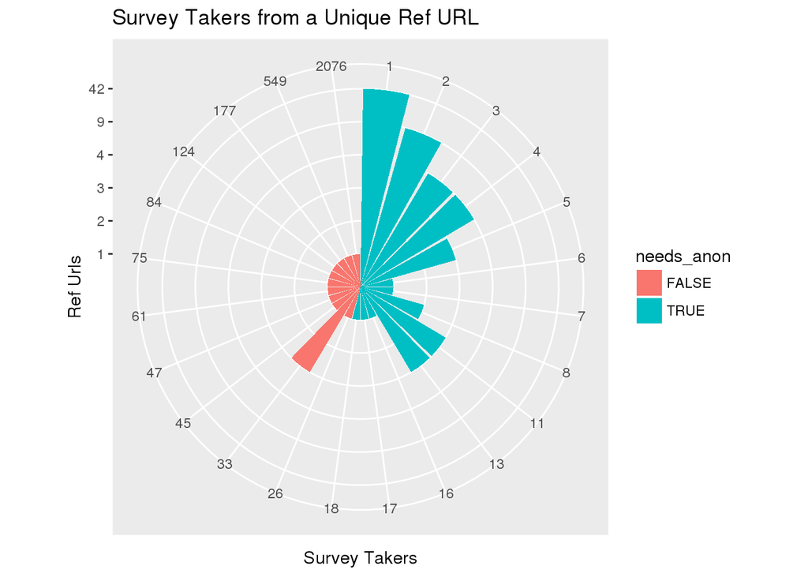

```r
ggplot(refurl_summary_summary,
       aes(y=factor(total_refurls), x=factor(total_respondants))) +
  geom_bar(aes(fill=needs_anon), stat="identity") +
  coord_polar() +
  labs(y = "Ref Urls", x = "Survey Takers", title="Survey Takers from a Unique Ref URL")
```

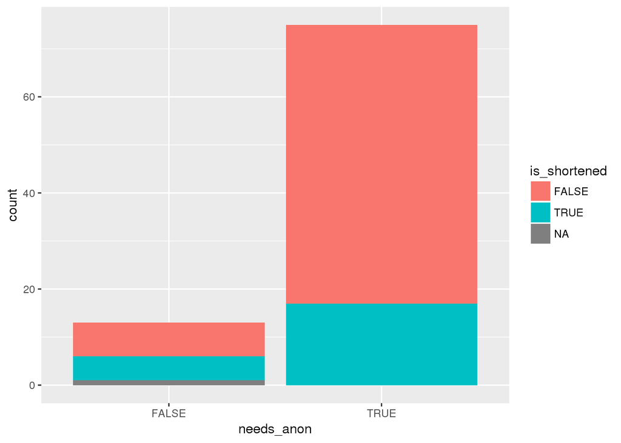

```r
ggplot(refurl_summary, aes(x=needs_anon, fill=is_shortened)) +
  geom_bar()
```

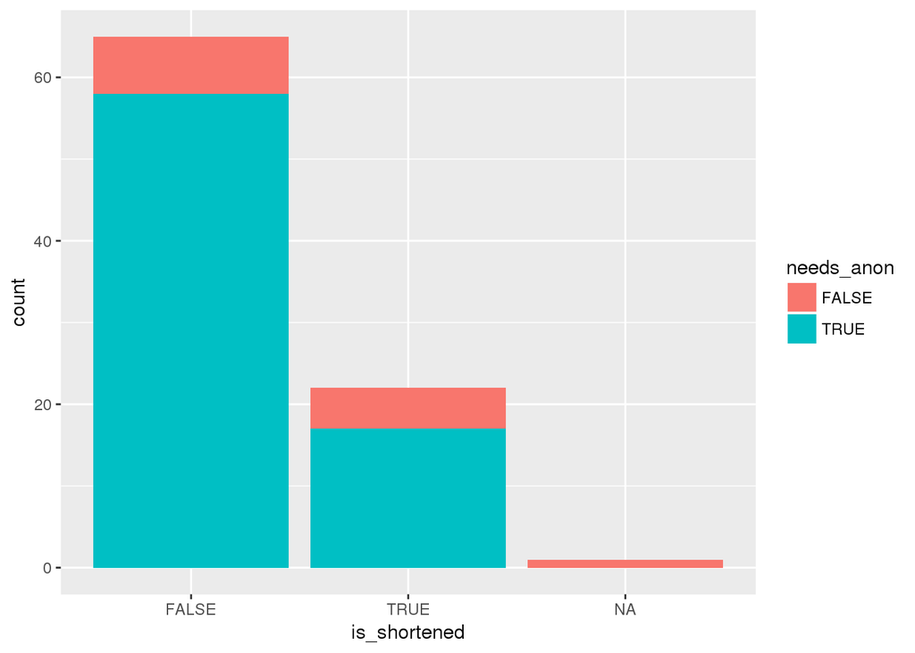

```r
ggplot(refurl_summary, aes(x=is_shortened, fill=needs_anon)) +
  geom_bar()
```

```r
# TODO resolve t.co urls, those are masking other referrals
# Options - extract domain for all (simplest), only extract domain for < 100 respondants

# If based on respondants: 1) clean URLS - remove protocol (^.*//), trailing (/$), and query params (\\?.*), summarize respondants, extract domain if > 100

# If just domain, then just extract the domain
```